# HNB DigiMedia Map 7: Content Amplification Chains

Tracing How Official Communication Propagates Through the Media Ecosystem

Author

HNB DigiMedia Project

Published

January 28, 2026

# 1 Introduction

This document presents **Map 7: Content Amplification Chains** of the HNB DigiMedia project. The core question driving this analysis is:

> **When HNB publishes official communication, how does it propagate through the media ecosystem, and where does message transformation occur?**

## 1.1 Theoretical Motivation

The literature establishes a critical finding: Coibion, Gorodnichenko, and Weber (2022) found that reading FOMC statements has “about the same average effect on expectations as simply being told the Fed’s inflation target” while news articles had half that effect. This suggests:

1. **Amplification matters:** Media intermediation determines whether official communication reaches the public
2. **Transformation risk:** Each amplification step introduces potential message distortion
3. **Timing dynamics:** Speed of amplification affects policy transmission

Understanding the amplification chain reveals:

- How quickly media responds to HNB publications
- Which sources serve as primary amplifiers vs secondary echo chambers
- Whether amplification preserves or transforms the original message
- The multiplication factor between official publication and total ecosystem REACH

## 1.2 Amplification Framework

We conceptualize the amplification chain as:

```
HNB Official Publication → Primary Amplifiers → Secondary Echo → Long-tail Coverage
     (Day 0)                  (Day 0-1)           (Day 2-3)        (Day 4+)
```

| Stage | Definition | Characteristics |
| --- | --- | --- |
| Source | HNB Official publication | Authoritative, technical, low REACH |
| Primary Amplifier | Coverage within 24 hours | News breaking, high REACH potential |
| Secondary Echo | Coverage 2-3 days after | Analysis, commentary, opinion |
| Long-tail | Coverage 4+ days after | Background reference, archival |

```r
hnb <- readRDS("C:/Users/lsikic/Dropbox/hnb.rds")
setDT(hnb)

hnb[, date := as.Date(DATE)]
hnb[, year := year(date)]
hnb[, month := month(date)]

hnb[, period := fcase(
  date < as.Date("2023-01-01"), "ERM II",
  default = "Euro Era"
)]
hnb[, period := factor(period, levels = c("ERM II", "Euro Era"))]

n_articles <- nrow(hnb)
n_sources <- uniqueN(hnb$FROM)

cat("Data loaded:", n_articles, "articles from", n_sources, "sources\n")
```

```
Data loaded: 19128 articles from 894 sources
```

```r
# =============================================================================
# ACTOR CLASSIFICATION - SYNCHRONIZED WITH MAPS 1-6
# =============================================================================

manual_overrides <- list(
  "HNB Official" = c(
    "hnb.hr", "hrvatska narodna banka",
    "hrvatska narodna banka / croatian national bank"
  ),
  "Financial Regulators" = c(
    "hanfa.hr", "hanfa", "hrvatska agencija za nadzor financijskih usluga",
    "fina.hr", "fina", "financijska agencija"
  ),
  "Government" = c(
    "gov.hr", "vlada", "vlada republike hrvatske",
    "ministarstvo financija", "sabor.hr"
  ),
  "Financial Media" = c(
    "poslovni.hr", "poslovni dnevnik", "seebiz.eu", "seebiz",
    "lider.media", "lidermedia.hr", "lider", "bloombergadria.com",
    "bloomberg adria", "hrportfolio.hr", "privredni.hr"
  ),
  "Commercial Banks" = c(
    "zaba.hr", "zagrebačka banka", "pbz.hr", "privredna banka zagreb",
    "erste.hr", "erste banka", "hpb.hr", "hrvatska poštanska banka",
    "otp banka", "raiffeisen", "addiko"
  ),
  "Academic/Expert" = c(
    "eizg.hr", "ekonomski institut zagreb", "ijf.hr",
    "institut za javne financije", "ekonomski fakultet"
  )
)

general_media_sources <- c(
  "index.hr", "index", "jutarnji.hr", "jutarnji", "jutarnji list",
  "vecernji.hr", "vecernji", "večernji list",
  "24sata.hr", "24sata", "slobodnadalmacija.hr", "slobodna dalmacija",
  "novilist.hr", "novi list", "dnevnik.hr", "dnevnik",
  "tportal.hr", "tportal", "telegram.hr", "telegram",
  "net.hr", "rtl.hr", "rtl", "hrt.hr", "hrt",
  "n1info.hr", "n1info.com", "n1", "nacional.hr", "nacional",
  "direktno.hr", "direktno", "dnevno.hr", "dnevno"
)

classify_actor_hnb <- function(from_val, url_val = NA) {
  from_lower <- tolower(trimws(as.character(from_val)))
  url_lower <- tolower(ifelse(is.na(url_val), "", as.character(url_val)))
  combined <- paste(from_lower, url_lower)

  match_any <- function(patterns, text, fixed = TRUE) {
    any(sapply(patterns, function(p) grepl(p, text, fixed = fixed)))
  }

  for (actor_type in names(manual_overrides)) {
    if (match_any(manual_overrides[[actor_type]], from_lower)) {
      return(actor_type)
    }
  }

  if (grepl("hnb\\.hr", url_lower) || grepl("hnb\\.hr", from_lower)) {
    return("HNB Official")
  }

  if (grepl("hanfa|fina\\.hr", combined)) {
    return("Financial Regulators")
  }

  if (grepl("gov\\.hr|vlada|ministarstvo", combined)) {
    return("Government")
  }

  bank_patterns <- c("banka", "bank", "zaba", "pbz", "erste", "hpb",
                     "otp", "raiffeisen", "addiko", "sberbank")
  if (match_any(bank_patterns, from_lower)) {
    if (!grepl("narodna|hnb|central", from_lower)) {
      return("Commercial Banks")
    }
  }

  financial_media_patterns <- c(
    "poslovni", "seebiz", "lider", "bloomberg", "portfolio",
    "privredni", "finance", "ekonom", "business", "capital"
  )
  if (match_any(financial_media_patterns, from_lower)) {
    return("Financial Media")
  }

  if (match_any(general_media_sources, from_lower)) {
    return("General Media")
  }

  news_patterns <- c("portal", "vijesti", "news", "info", "dnevni",
                     "radio", "tv", ".hr")
  if (match_any(news_patterns, from_lower)) {
    return("General Media")
  }

  return("Other")
}

hnb[, ACTOR_TYPE := mapply(classify_actor_hnb, FROM, URL)]
hnb[, INSTITUTIONAL := ACTOR_TYPE %in% c("HNB Official", "Financial Regulators", "Government")]
```

# 2 Analysis 7.1: HNB Publication Patterns

## 2.1 Identifying HNB Official Publications

```r
# Extract HNB Official publications
hnb_official <- hnb[ACTOR_TYPE == "HNB Official"]

cat("HNB Official Publications\n")
```

```
HNB Official Publications
```

```r
cat("=========================\n")
cat("Total HNB publications:", nrow(hnb_official), "\n")
```

```
Total HNB publications: 415
```

```r
cat("Date range:", as.character(min(hnb_official$date)), "to", as.character(max(hnb_official$date)), "\n")
```

```
Date range: 2021-01-04 to 2023-12-29
```

```r
cat("Total REACH:", format(sum(hnb_official$REACH, na.rm = TRUE), big.mark = ","), "\n")
```

```
Total REACH: 567,340
```

```r
# Publication frequency
hnb_daily <- hnb_official[, .(Publications = .N), by = date]
cat("Days with publications:", nrow(hnb_daily), "\n")
```

```
Days with publications: 257
```

```r
cat("Mean publications per active day:", sprintf("%.1f", mean(hnb_daily$Publications)), "\n")
```

```
Mean publications per active day: 1.6
```

## 2.2 HNB Publication Timeline

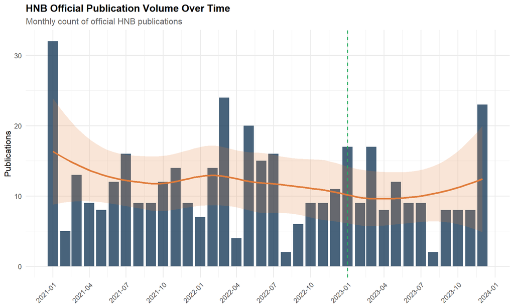

```r
hnb_monthly <- hnb_official[, .(
  Publications = .N,
  Total_REACH = sum(REACH, na.rm = TRUE)
), by = .(year, month)]

hnb_monthly[, date_month := as.Date(paste(year, month, "01", sep = "-"))]

ggplot(hnb_monthly, aes(x = date_month, y = Publications)) +
  geom_col(fill = "#1a3c5a", alpha = 0.8) +
  geom_smooth(method = "loess", se = TRUE, color = "#e07b39", fill = "#e07b39", alpha = 0.2) +
  geom_vline(xintercept = as.Date("2023-01-01"), linetype = "dashed", color = "#27ae60") +
  scale_x_date(date_labels = "%Y-%m", date_breaks = "3 months") +
  labs(
    title = "HNB Official Publication Volume Over Time",
    subtitle = "Monthly count of official HNB publications",
    x = NULL,
    y = "Publications"
  ) +
  theme(axis.text.x = element_text(angle = 45, hjust = 1))
```

# 3 Analysis 7.2: Amplification Response Time

## 3.1 Media Response Lag Analysis

For each day with HNB publications, we measure how quickly media sources respond.

```r
# Get dates when HNB published
hnb_pub_dates <- unique(hnb_official$date)

# For each HNB publication date, find media coverage in following days
amplification_data <- data.table()

for (pub_date in hnb_pub_dates) {
  pub_date <- as.Date(pub_date, origin = "1970-01-01")

  # Get media coverage in 0-14 day window after HNB publication
  window_coverage <- hnb[ACTOR_TYPE != "HNB Official" &
                          date >= pub_date &
                          date <= pub_date + 14]

  if (nrow(window_coverage) > 0) {
    window_coverage[, `:=`(
      HNB_Pub_Date = pub_date,
      Lag_Days = as.integer(date - pub_date)
    )]

    amplification_data <- rbind(amplification_data, window_coverage)
  }
}

# Categorize lag
amplification_data[, Lag_Category := fcase(
  Lag_Days == 0, "Same day",
  Lag_Days == 1, "1 day",
  Lag_Days <= 3, "2-3 days",
  Lag_Days <= 7, "4-7 days",
  default = "8+ days"
)]

amplification_data[, Lag_Category := factor(Lag_Category,
                                            levels = c("Same day", "1 day", "2-3 days", "4-7 days", "8+ days"))]

cat("Amplification Analysis\n")
```

```
Amplification Analysis
```

```r
cat("======================\n")
cat("HNB publication days analyzed:", length(hnb_pub_dates), "\n")
```

```
HNB publication days analyzed: 257
```

```r
cat("Total media articles in response windows:", nrow(amplification_data), "\n")
```

```
Total media articles in response windows: 71351
```

## 3.2 Response Time Distribution

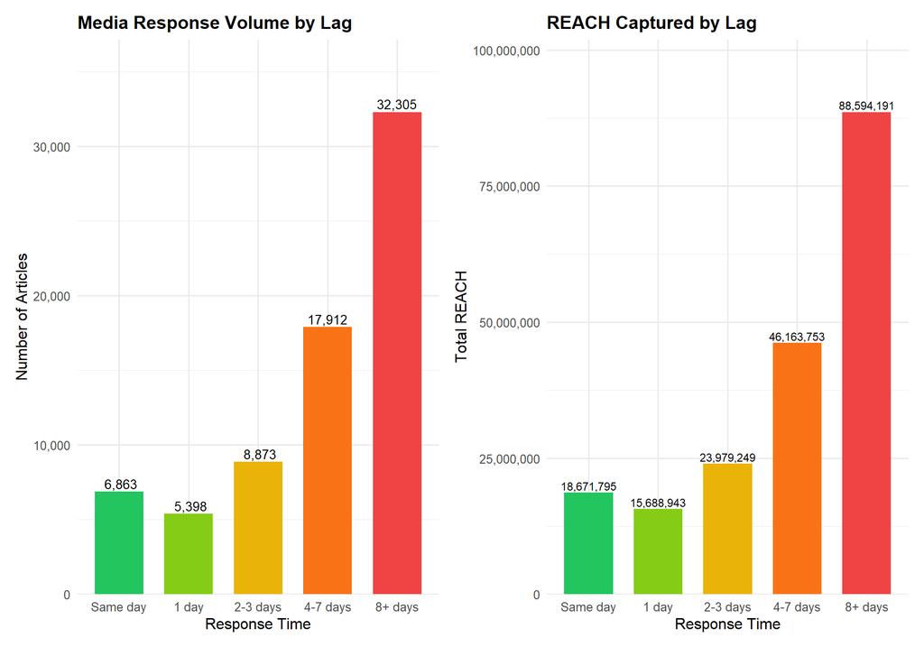

```r
lag_summary <- amplification_data[, .(
  Articles = .N,
  Total_REACH = sum(REACH, na.rm = TRUE),
  Mean_REACH = mean(REACH, na.rm = TRUE),
  Sources = uniqueN(FROM)
), by = Lag_Category]

lag_summary[, `:=`(
  Article_Share = Articles / sum(Articles) * 100,
  REACH_Share = Total_REACH / sum(Total_REACH) * 100
)]

p1 <- ggplot(lag_summary, aes(x = Lag_Category, y = Articles, fill = Lag_Category)) +
  geom_col(width = 0.7) +
  geom_text(aes(label = format(Articles, big.mark = ",")), vjust = -0.3, size = 3.5) +
  scale_fill_manual(values = lag_colors) +
  scale_y_continuous(labels = comma, expand = expansion(mult = c(0, 0.15))) +
  labs(
    title = "Media Response Volume by Lag",
    x = "Response Time",
    y = "Number of Articles"
  ) +
  theme(legend.position = "none")

p2 <- ggplot(lag_summary, aes(x = Lag_Category, y = Total_REACH, fill = Lag_Category)) +
  geom_col(width = 0.7) +
  geom_text(aes(label = format(Total_REACH, big.mark = ",")), vjust = -0.3, size = 3) +
  scale_fill_manual(values = lag_colors) +
  scale_y_continuous(labels = comma, expand = expansion(mult = c(0, 0.15))) +
  labs(
    title = "REACH Captured by Lag",
    x = "Response Time",
    y = "Total REACH"
  ) +
  theme(legend.position = "none")

p1 + p2
```

## 3.3 Response Time Summary Table

```r
lag_summary %>%
  mutate(
    Articles = format(Articles, big.mark = ","),
    Total_REACH = format(Total_REACH, big.mark = ","),
    Mean_REACH = format(round(Mean_REACH, 0), big.mark = ","),
    Sources = format(Sources, big.mark = ","),
    Article_Share = sprintf("%.1f%%", Article_Share),
    REACH_Share = sprintf("%.1f%%", REACH_Share)
  ) %>%
  kable(col.names = c("Response Time", "Articles", "Total REACH", "Mean REACH",
                      "Sources", "Article %", "REACH %")) %>%
  kable_styling(bootstrap_options = c("striped", "hover"), full_width = FALSE)
```

| Response Time | Articles | Total REACH | Mean REACH | Sources | Article % | REACH % |
| --- | --- | --- | --- | --- | --- | --- |
| 1 day | 5,398 | 15,688,943 | 2,933 | 503 | 7.6% | 8.1% |
| Same day | 6,863 | 18,671,795 | 2,746 | 547 | 9.6% | 9.7% |
| 2-3 days | 8,873 | 23,979,249 | 2,729 | 590 | 12.4% | 12.4% |
| 4-7 days | 17,912 | 46,163,753 | 2,598 | 717 | 25.1% | 23.9% |
| 8+ days | 32,305 | 88,594,191 | 2,770 | 828 | 45.3% | 45.9% |

## 3.4 Cumulative Amplification Curve

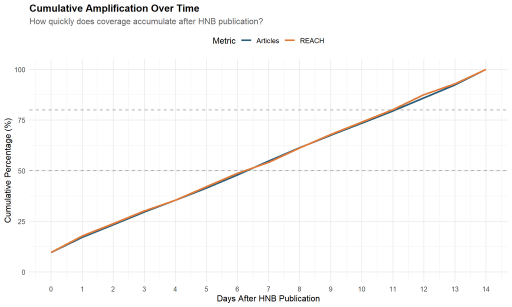

```r
# Daily cumulative amplification
daily_amp <- amplification_data[, .(
  Articles = .N,
  Total_REACH = sum(REACH, na.rm = TRUE)
), by = Lag_Days][order(Lag_Days)]

daily_amp[, `:=`(
  Cumulative_Articles = cumsum(Articles),
  Cumulative_REACH = cumsum(Total_REACH)
)]

daily_amp[, `:=`(
  Cumulative_Article_Pct = Cumulative_Articles / sum(Articles) * 100,
  Cumulative_REACH_Pct = Cumulative_REACH / sum(Total_REACH) * 100
)]

ggplot(daily_amp, aes(x = Lag_Days)) +
  geom_line(aes(y = Cumulative_Article_Pct, color = "Articles"), linewidth = 1.2) +
  geom_line(aes(y = Cumulative_REACH_Pct, color = "REACH"), linewidth = 1.2) +
  geom_hline(yintercept = c(50, 80), linetype = "dashed", color = "gray50", alpha = 0.7) +
  scale_color_manual(values = c("Articles" = "#2c5f7c", "REACH" = "#e07b39")) +
  scale_x_continuous(breaks = 0:14) +
  scale_y_continuous(limits = c(0, 100)) +
  labs(
    title = "Cumulative Amplification Over Time",
    subtitle = "How quickly does coverage accumulate after HNB publication?",
    x = "Days After HNB Publication",
    y = "Cumulative Percentage (%)",
    color = "Metric"
  ) +
  theme(legend.position = "top")
```

# 4 Analysis 7.3: Primary Amplifiers

## 4.1 Who Responds First?

Sources that consistently publish within 24 hours of HNB communication serve as primary amplifiers.

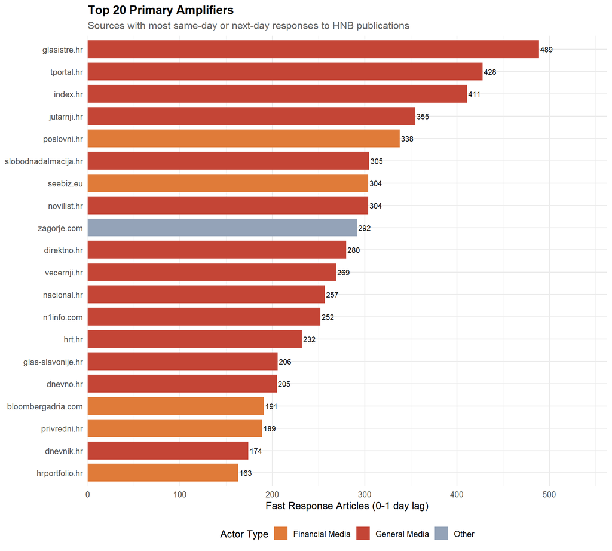

```r
# Primary amplifiers = same day or next day response
primary_amp <- amplification_data[Lag_Days <= 1]

primary_sources <- primary_amp[, .(
  Fast_Responses = .N,
  Total_REACH = sum(REACH, na.rm = TRUE),
  Mean_REACH = mean(REACH, na.rm = TRUE),
  Response_Days = uniqueN(HNB_Pub_Date),
  ACTOR_TYPE = first(ACTOR_TYPE)
), by = FROM][order(-Fast_Responses)]

primary_sources[, Response_Rate := Response_Days / length(hnb_pub_dates) * 100]

# Top 20 primary amplifiers
top_primary <- primary_sources[1:min(20, nrow(primary_sources))]

ggplot(top_primary, aes(x = reorder(FROM, Fast_Responses), y = Fast_Responses, fill = ACTOR_TYPE)) +
  geom_col(width = 0.8) +
  geom_text(aes(label = Fast_Responses), hjust = -0.1, size = 3) +
  coord_flip() +
  scale_fill_manual(values = actor_colors) +
  scale_y_continuous(expand = expansion(mult = c(0, 0.15))) +
  labs(
    title = "Top 20 Primary Amplifiers",
    subtitle = "Sources with most same-day or next-day responses to HNB publications",
    x = NULL,
    y = "Fast Response Articles (0-1 day lag)",
    fill = "Actor Type"
  )
```

## 4.2 Primary Amplifier Profiles

```r
primary_sources[1:min(20, nrow(primary_sources))] %>%
  mutate(
    Fast_Responses = format(Fast_Responses, big.mark = ","),
    Total_REACH = format(Total_REACH, big.mark = ","),
    Mean_REACH = format(round(Mean_REACH, 0), big.mark = ","),
    Response_Rate = sprintf("%.0f%%", Response_Rate)
  ) %>%
  select(FROM, ACTOR_TYPE, Fast_Responses, Response_Days, Response_Rate, Total_REACH, Mean_REACH) %>%
  kable(col.names = c("Source", "Actor Type", "Fast Responses", "Active Days",
                      "Response Rate", "Total REACH", "Mean REACH"),
        caption = "Top 20 Primary Amplifiers (0-1 day response)") %>%
  kable_styling(bootstrap_options = c("striped", "hover"), full_width = FALSE) %>%
  scroll_box(height = "500px")
```

Top 20 Primary Amplifiers (0-1 day response)

| Source | Actor Type | Fast Responses | Active Days | Response Rate | Total REACH | Mean REACH |
| --- | --- | --- | --- | --- | --- | --- |
| glasistre.hr | General Media | 489 | 211 | 82% | 257,310 | 526 |
| tportal.hr | General Media | 428 | 183 | 71% | 1,035,000 | 2,418 |
| index.hr | General Media | 411 | 176 | 68% | 5,300,703 | 12,992 |
| jutarnji.hr | General Media | 355 | 160 | 62% | 2,779,047 | 7,828 |
| poslovni.hr | Financial Media | 338 | 176 | 68% | 719,124 | 2,128 |
| slobodnadalmacija.hr | General Media | 305 | 140 | 54% | 1,146,318 | 3,771 |
| seebiz.eu | Financial Media | 304 | 173 | 67% | 7,298 | 24 |
| novilist.hr | General Media | 304 | 162 | 63% | 436,062 | 1,434 |
| zagorje.com | Other | 292 | 145 | 56% | 908,988 | 3,113 |
| direktno.hr | General Media | 280 | 156 | 61% | 258,714 | 927 |
| vecernji.hr | General Media | 269 | 145 | 56% | 1,316,949 | 5,027 |
| nacional.hr | General Media | 257 | 138 | 54% | 248,730 | 968 |
| n1info.com | General Media | 252 | 117 | 46% | 1,326,159 | 5,263 |
| hrt.hr | General Media | 232 | 133 | 52% | 160,680 | 693 |
| glas-slavonije.hr | General Media | 206 | 135 | 53% | 18,744 | 91 |
| dnevno.hr | General Media | 205 | 126 | 49% | 470,904 | 2,297 |
| bloombergadria.com | Financial Media | 191 | 87 | 34% | 35,973 | 188 |
| privredni.hr | Financial Media | 189 | 120 | 47% | 39,168 | 207 |
| dnevnik.hr | General Media | 174 | 104 | 40% | 991,620 | 5,699 |
| hrportfolio.hr | Financial Media | 163 | 121 | 47% | 15,906 | 98 |

## 4.3 Amplifier Actor Type Composition

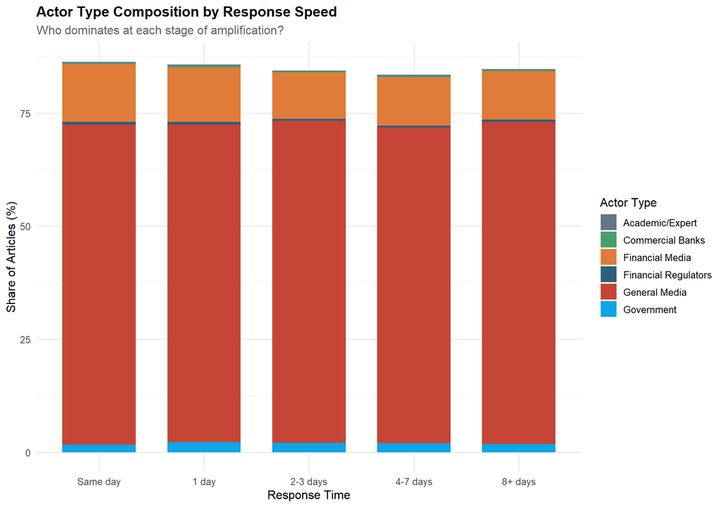

```r
# Compare actor type composition by response speed
amp_by_actor <- amplification_data[, .(
  Articles = .N,
  Total_REACH = sum(REACH, na.rm = TRUE)
), by = .(ACTOR_TYPE, Lag_Category)]

amp_by_actor[, `:=`(
  Article_Share = Articles / sum(Articles) * 100,
  REACH_Share = Total_REACH / sum(Total_REACH) * 100
), by = Lag_Category]

ggplot(amp_by_actor[ACTOR_TYPE != "Other"],
       aes(x = Lag_Category, y = Article_Share, fill = ACTOR_TYPE)) +
  geom_col(position = "stack", width = 0.7) +
  scale_fill_manual(values = actor_colors) +
  labs(
    title = "Actor Type Composition by Response Speed",
    subtitle = "Who dominates at each stage of amplification?",
    x = "Response Time",
    y = "Share of Articles (%)",
    fill = "Actor Type"
  ) +
  theme(legend.position = "right")
```

# 5 Analysis 7.4: Amplification Multiplier

## 5.1 REACH Multiplication Effect

For every unit of REACH from HNB Official, how much total ecosystem REACH is generated?

```r
# Total HNB Official REACH
hnb_reach <- sum(hnb_official$REACH, na.rm = TRUE)

# Total media REACH in response windows
media_reach <- sum(amplification_data$REACH, na.rm = TRUE)

# Amplification multiplier
amplification_multiplier <- media_reach / hnb_reach

# By time window
multiplier_by_lag <- lag_summary[, .(
  Lag_Category,
  REACH = Total_REACH,
  Multiplier = Total_REACH / hnb_reach
)]

cat("Amplification Multiplier Analysis\n")
```

```
Amplification Multiplier Analysis
```

```r
cat("==================================\n")
cat("HNB Official total REACH:", format(hnb_reach, big.mark = ","), "\n")
```

```
HNB Official total REACH: 567,340
```

```r
cat("Media ecosystem REACH (0-14 days):", format(media_reach, big.mark = ","), "\n")
```

```
Media ecosystem REACH (0-14 days): 193,097,931
```

```r
cat("Overall amplification multiplier:", sprintf("%.1fx", amplification_multiplier), "\n")
```

```
Overall amplification multiplier: 340.4x
```

```r
cat("\nThis means for every 1 unit of HNB Official REACH,\n")
```

```
This means for every 1 unit of HNB Official REACH,
```

```r
cat("the media ecosystem generates", sprintf("%.1f", amplification_multiplier), "additional units.\n")
```

```
the media ecosystem generates 340.4 additional units.
```

## 5.2 Multiplier by Response Time

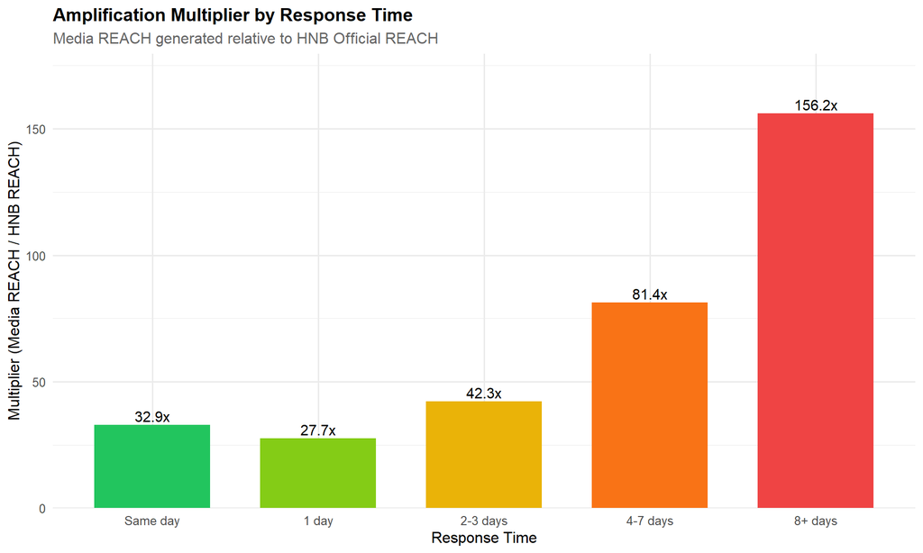

```r
multiplier_by_lag[, Cumulative_Multiplier := cumsum(Multiplier)]

ggplot(multiplier_by_lag, aes(x = Lag_Category, y = Multiplier, fill = Lag_Category)) +
  geom_col(width = 0.7) +
  geom_text(aes(label = sprintf("%.1fx", Multiplier)), vjust = -0.3, size = 4) +
  scale_fill_manual(values = lag_colors) +
  scale_y_continuous(expand = expansion(mult = c(0, 0.15))) +
  labs(
    title = "Amplification Multiplier by Response Time",
    subtitle = "Media REACH generated relative to HNB Official REACH",
    x = "Response Time",
    y = "Multiplier (Media REACH / HNB REACH)"
  ) +
  theme(legend.position = "none")
```

## 5.3 Multiplier Summary

```r
multiplier_by_lag %>%
  mutate(
    REACH = format(REACH, big.mark = ","),
    Multiplier = sprintf("%.2fx", Multiplier),
    Cumulative_Multiplier = sprintf("%.2fx", Cumulative_Multiplier)
  ) %>%
  kable(col.names = c("Response Time", "Media REACH", "Multiplier", "Cumulative Multiplier")) %>%
  kable_styling(bootstrap_options = c("striped", "hover"), full_width = FALSE)
```

| Response Time | Media REACH | Multiplier | Cumulative Multiplier |
| --- | --- | --- | --- |
| 1 day | 15,688,943 | 27.65x | 27.65x |
| Same day | 18,671,795 | 32.91x | 60.56x |
| 2-3 days | 23,979,249 | 42.27x | 102.83x |
| 4-7 days | 46,163,753 | 81.37x | 184.20x |
| 8+ days | 88,594,191 | 156.16x | 340.36x |

# 6 Analysis 7.5: Content Similarity Analysis

## 6.1 Title/Headline Comparison

Do media headlines preserve or transform HNB messaging? We analyze textual similarity between HNB titles and subsequent media coverage.

```r
# Sample HNB publications with clear titles
hnb_titles <- hnb_official[!is.na(TITLE) & nchar(TITLE) > 20, .(date, TITLE, REACH)]
setnames(hnb_titles, "TITLE", "HNB_TITLE")

# For each HNB publication, find media articles on same/next day
similarity_data <- data.table()

for (i in 1:min(100, nrow(hnb_titles))) {  # Sample for performance
  pub_date <- hnb_titles$date[i]
  hnb_title <- hnb_titles$HNB_TITLE[i]

  # Get same-day and next-day media coverage
  media_coverage <- hnb[ACTOR_TYPE != "HNB Official" &
                         date >= pub_date &
                         date <= pub_date + 1 &
                         !is.na(TITLE) & nchar(TITLE) > 20]

  if (nrow(media_coverage) > 0) {
    # Calculate Jaccard similarity for titles
    for (j in 1:nrow(media_coverage)) {
      media_title <- media_coverage$TITLE[j]

      # Tokenize and calculate Jaccard similarity
      hnb_tokens <- unique(tolower(unlist(strsplit(hnb_title, "\\s+"))))
      media_tokens <- unique(tolower(unlist(strsplit(media_title, "\\s+"))))

      intersection <- length(intersect(hnb_tokens, media_tokens))
      union <- length(union(hnb_tokens, media_tokens))
      jaccard <- intersection / union

      similarity_data <- rbind(similarity_data, data.table(
        HNB_Date = pub_date,
        HNB_Title = hnb_title,
        Media_Source = media_coverage$FROM[j],
        Media_Title = media_title,
        Media_ACTOR = media_coverage$ACTOR_TYPE[j],
        Media_REACH = media_coverage$REACH[j],
        Jaccard_Similarity = jaccard,
        Lag_Days = as.integer(media_coverage$date[j] - pub_date)
      ))
    }
  }
}

if (nrow(similarity_data) > 0) {
  cat("Title Similarity Analysis\n")
  cat("=========================\n")
  cat("HNB-Media title pairs analyzed:", nrow(similarity_data), "\n")
  cat("Mean Jaccard similarity:", sprintf("%.3f", mean(similarity_data$Jaccard_Similarity)), "\n")
  cat("Median Jaccard similarity:", sprintf("%.3f", median(similarity_data$Jaccard_Similarity)), "\n")
}
```

```
Title Similarity Analysis
=========================
HNB-Media title pairs analyzed: 4059
Mean Jaccard similarity: 0.050
Median Jaccard similarity: 0.000
```

## 6.2 Similarity Distribution

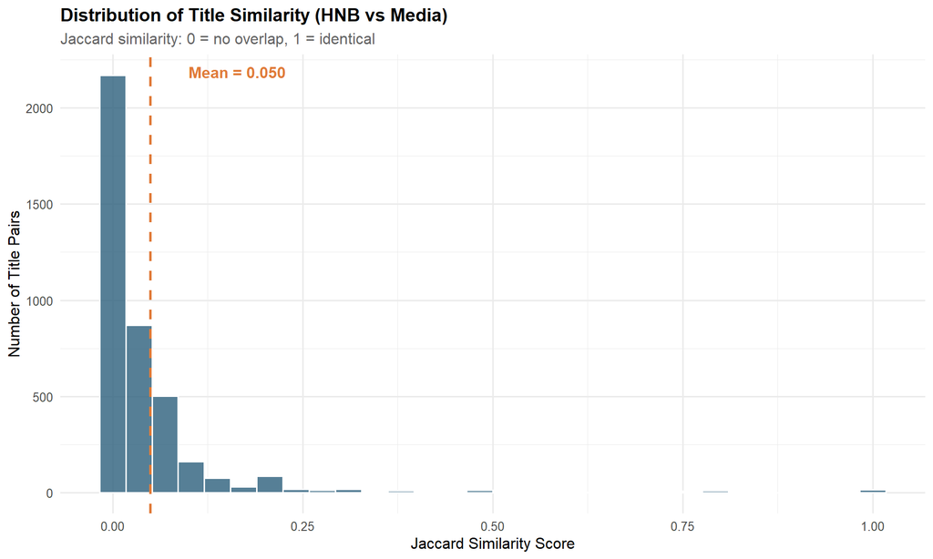

```r
if (nrow(similarity_data) > 0) {
  ggplot(similarity_data, aes(x = Jaccard_Similarity)) +
    geom_histogram(bins = 30, fill = "#2c5f7c", color = "white", alpha = 0.8) +
    geom_vline(xintercept = mean(similarity_data$Jaccard_Similarity),
               linetype = "dashed", color = "#e07b39", linewidth = 1) +
    annotate("text", x = mean(similarity_data$Jaccard_Similarity) + 0.05, y = Inf,
             label = paste0("Mean = ", sprintf("%.3f", mean(similarity_data$Jaccard_Similarity))),
             vjust = 2, hjust = 0, color = "#e07b39", fontface = "bold") +
    labs(
      title = "Distribution of Title Similarity (HNB vs Media)",
      subtitle = "Jaccard similarity: 0 = no overlap, 1 = identical",
      x = "Jaccard Similarity Score",
      y = "Number of Title Pairs"
    )
}
```

## 6.3 Similarity by Actor Type

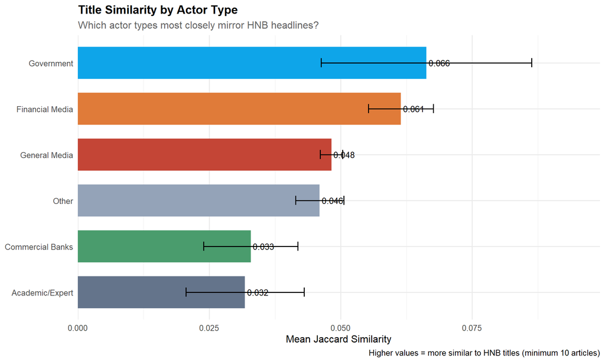

```r
if (nrow(similarity_data) > 0) {
  similarity_by_actor <- similarity_data[, .(
    Mean_Similarity = mean(Jaccard_Similarity),
    Median_Similarity = median(Jaccard_Similarity),
    SD_Similarity = sd(Jaccard_Similarity),
    Articles = .N,
    Mean_REACH = mean(Media_REACH, na.rm = TRUE)
  ), by = Media_ACTOR][order(-Mean_Similarity)]

  ggplot(similarity_by_actor[Articles >= 10],
         aes(x = reorder(Media_ACTOR, Mean_Similarity), y = Mean_Similarity, fill = Media_ACTOR)) +
    geom_col(width = 0.7) +
    geom_errorbar(aes(ymin = Mean_Similarity - SD_Similarity/sqrt(Articles),
                      ymax = Mean_Similarity + SD_Similarity/sqrt(Articles)),
                  width = 0.2) +
    geom_text(aes(label = sprintf("%.3f", Mean_Similarity)), hjust = -0.1, size = 3.5) +
    coord_flip() +
    scale_fill_manual(values = actor_colors) +
    scale_y_continuous(expand = expansion(mult = c(0, 0.15))) +
    labs(
      title = "Title Similarity by Actor Type",
      subtitle = "Which actor types most closely mirror HNB headlines?",
      x = NULL,
      y = "Mean Jaccard Similarity",
      caption = "Higher values = more similar to HNB titles (minimum 10 articles)"
    ) +
    theme(legend.position = "none")
}
```

## 6.4 High vs Low Similarity Examples

```r
if (nrow(similarity_data) > 0) {
  # High similarity examples
  high_sim <- similarity_data[order(-Jaccard_Similarity)][1:min(10, nrow(similarity_data))]

  cat("Examples of HIGH Similarity (preserving HNB framing):\n")
  cat("=====================================================\n\n")

  for (i in 1:min(5, nrow(high_sim))) {
    cat("Similarity:", sprintf("%.3f", high_sim$Jaccard_Similarity[i]), "\n")
    cat("HNB:", substr(high_sim$HNB_Title[i], 1, 80), "...\n")
    cat("Media:", substr(high_sim$Media_Title[i], 1, 80), "...\n")
    cat("Source:", high_sim$Media_Source[i], "\n\n")
  }

  # Low similarity examples (possible transformation)
  low_sim <- similarity_data[Jaccard_Similarity > 0][order(Jaccard_Similarity)][1:min(10, nrow(similarity_data))]

  cat("\nExamples of LOW Similarity (potential reframing):\n")
  cat("==================================================\n\n")

  for (i in 1:min(5, nrow(low_sim))) {
    cat("Similarity:", sprintf("%.3f", low_sim$Jaccard_Similarity[i]), "\n")
    cat("HNB:", substr(low_sim$HNB_Title[i], 1, 80), "...\n")
    cat("Media:", substr(low_sim$Media_Title[i], 1, 80), "...\n")
    cat("Source:", low_sim$Media_Source[i], "\n\n")
  }
}
```

```
Examples of HIGH Similarity (preserving HNB framing):
=====================================================

Similarity: 1.000
HNB: Građani će sudjelovati u odabiru motiva na nacionalnoj strani eurokovanica ...
Media: Građani će sudjelovati u odabiru motiva na nacionalnoj strani eurokovanica ...
Source: radiodalmacija.hr

Similarity: 1.000
HNB: Građani će sudjelovati u odabiru motiva na nacionalnoj strani eurokovanica ...
Media: Građani će sudjelovati u odabiru motiva na nacionalnoj strani eurokovanica ...
Source: hia.com.hr

Similarity: 1.000
HNB: Građani će sudjelovati u odabiru motiva na nacionalnoj strani eurokovanica ...
Media: Građani će sudjelovati u odabiru motiva na nacionalnoj strani eurokovanica ...
Source: radio-banovina.hr

Similarity: 1.000
HNB: Građani će sudjelovati u odabiru motiva na nacionalnoj strani eurokovanica ...
Media: Građani će sudjelovati u odabiru motiva na nacionalnoj strani eurokovanica ...
Source: gov.hr

Similarity: 1.000
HNB: Hrvatska narodna banka: Preuzimamo obveze u cilju borbe protiv klimatskih promje ...
Media: Hrvatska narodna banka: Preuzimamo obveze u cilju borbe protiv klimatskih promje ...
Source: svijetosiguranja.eu


Examples of LOW Similarity (potential reframing):
==================================================

Similarity: 0.016
HNB: Otvoreni natječaj za izbor dizajna nacionalne strane Republike Hrvatske na optje ...
Media: [Betteridge's law of headlines, also known as Davis' law, is an adage that state ...
Source: croatia

Similarity: 0.016
HNB: Odluka o načinu obračuna, naplate i plaćanja kamata i naknada HNB-a ...
Media: Nedavno sam morala usitniti novac, a bila je nedjelja. Naravno da ne radi ništa  ...
Source: croatia

Similarity: 0.016
HNB: Održana Svečana akademija u povodu 30 godina hrvatske središnje banke ...
Media: Nedavno sam morala usitniti novac, a bila je nedjelja. Naravno da ne radi ništa  ...
Source: croatia

Similarity: 0.018
HNB: Hrvatska narodna banka upozorava na rizike koji nastaju za korisnike prilikom ko ...
Media: Večeras u Dnevniku pogledajte: ➡️ Ursula von der Leyen u Zagrebu predala pozitiv ...
Source: Moj HRT

Similarity: 0.019
HNB: U 30 godina svog djelovanja Hrvatska narodna banka se razvila u suvremenu, samos ...
Media: MILANOVIĆ O UVOĐENJU EURA: ‘S dozom sjete ću reći da gubimo svoju valutu i svoj  ...
Source: dnevno.hr
```

# 7 Analysis 7.6: Period Comparison

## 7.1 Amplification Dynamics: ERM II vs Euro Era

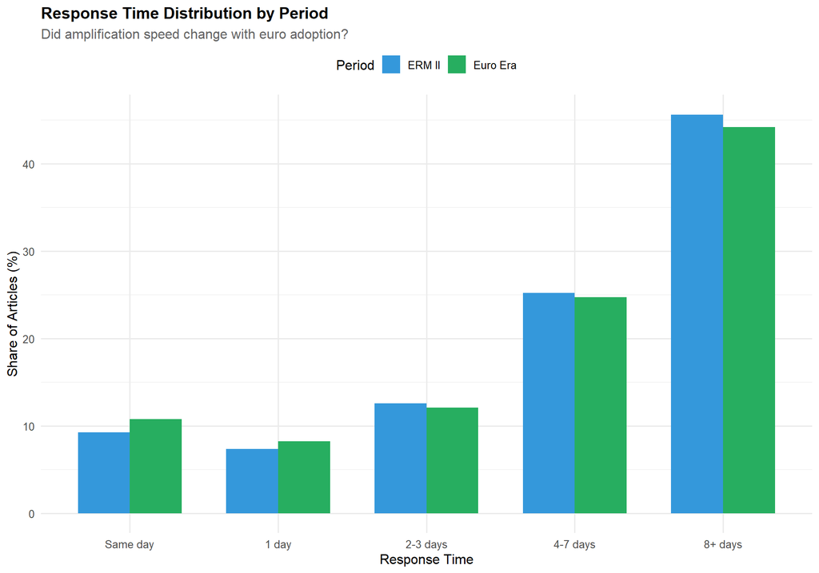

```r
amplification_data[, period := fcase(
  HNB_Pub_Date < as.Date("2023-01-01"), "ERM II",
  default = "Euro Era"
)]

period_amp <- amplification_data[, .(
  Articles = .N,
  Total_REACH = sum(REACH, na.rm = TRUE),
  Mean_REACH = mean(REACH, na.rm = TRUE),
  Sources = uniqueN(FROM)
), by = .(period, Lag_Category)]

period_amp[, Article_Share := Articles / sum(Articles) * 100, by = period]

ggplot(period_amp, aes(x = Lag_Category, y = Article_Share, fill = period)) +
  geom_col(position = "dodge", width = 0.7) +
  scale_fill_manual(values = period_colors) +
  labs(
    title = "Response Time Distribution by Period",
    subtitle = "Did amplification speed change with euro adoption?",
    x = "Response Time",
    y = "Share of Articles (%)",
    fill = "Period"
  ) +
  theme(legend.position = "top")
```

## 7.2 Period Amplification Metrics

```r
# HNB REACH by period
hnb_reach_period <- hnb_official[, .(HNB_REACH = sum(REACH, na.rm = TRUE)), by = period]

# Media REACH by period
media_reach_period <- amplification_data[, .(
  Media_REACH = sum(REACH, na.rm = TRUE),
  Articles = .N,
  Fast_Response_Pct = sum(Lag_Days <= 1) / .N * 100
), by = period]

period_multiplier <- merge(hnb_reach_period, media_reach_period, by = "period")
period_multiplier[, Multiplier := Media_REACH / HNB_REACH]

period_multiplier %>%
  mutate(
    HNB_REACH = format(HNB_REACH, big.mark = ","),
    Media_REACH = format(Media_REACH, big.mark = ","),
    Articles = format(Articles, big.mark = ","),
    Fast_Response_Pct = sprintf("%.1f%%", Fast_Response_Pct),
    Multiplier = sprintf("%.1fx", Multiplier)
  ) %>%
  kable(col.names = c("Period", "HNB REACH", "Media REACH", "Articles",
                      "Fast Response %", "Multiplier")) %>%
  kable_styling(bootstrap_options = c("striped", "hover"), full_width = FALSE)
```

| Period | HNB REACH | Media REACH | Articles | Fast Response % | Multiplier |
| --- | --- | --- | --- | --- | --- |
| ERM II | 438,453 | 156,068,655 | 54,198 | 16.6% | 356.0x |
| Euro Era | 128,887 | 37,029,276 | 17,153 | 19.0% | 287.3x |

# 8 Analysis 7.7: Amplification Network

## 8.1 Source-to-Source Amplification Patterns

Which sources most consistently amplify HNB content?

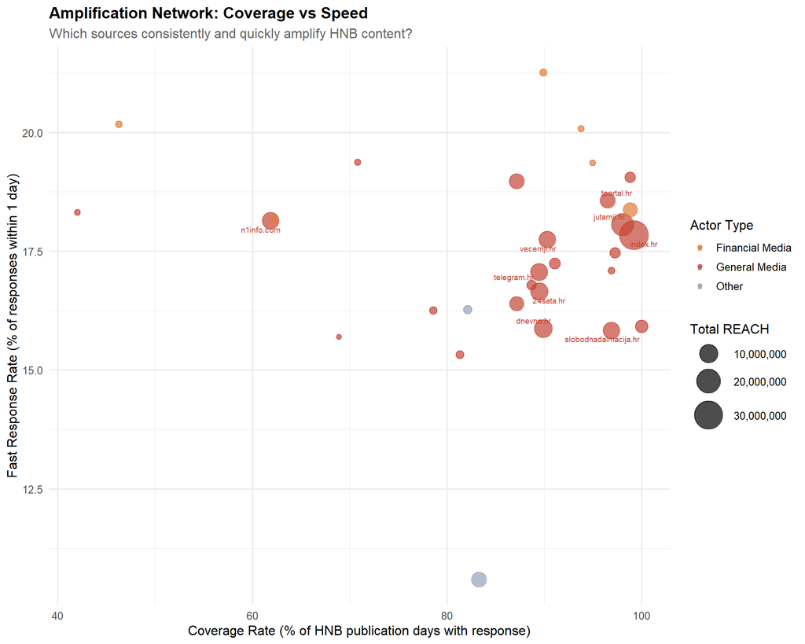

```r
# Sources that most frequently respond to HNB publications
source_response <- amplification_data[, .(
  Total_Responses = .N,
  Fast_Responses = sum(Lag_Days <= 1),
  Total_REACH = sum(REACH, na.rm = TRUE),
  Mean_Lag = mean(Lag_Days),
  Response_Days = uniqueN(HNB_Pub_Date),
  ACTOR_TYPE = first(ACTOR_TYPE)
), by = FROM][order(-Total_Responses)]

source_response[, `:=`(
  Fast_Response_Rate = Fast_Responses / Total_Responses * 100,
  Coverage_Rate = Response_Days / length(hnb_pub_dates) * 100
)]

# Top 30 most responsive sources
top_responsive <- source_response[1:min(30, nrow(source_response))]

ggplot(top_responsive, aes(x = Coverage_Rate, y = Fast_Response_Rate,
                           size = Total_REACH, color = ACTOR_TYPE)) +
  geom_point(alpha = 0.7) +
  geom_text_repel(aes(label = ifelse(Total_REACH > quantile(Total_REACH, 0.7), FROM, "")),
                  size = 2.5, max.overlaps = 15) +
  scale_size_continuous(labels = comma, range = c(2, 12)) +
  scale_color_manual(values = actor_colors) +
  labs(
    title = "Amplification Network: Coverage vs Speed",
    subtitle = "Which sources consistently and quickly amplify HNB content?",
    x = "Coverage Rate (% of HNB publication days with response)",
    y = "Fast Response Rate (% of responses within 1 day)",
    size = "Total REACH",
    color = "Actor Type"
  ) +
  theme(legend.position = "right")
```

## 8.2 Key Amplifier Profiles

```r
# Define "key amplifiers" as sources with high coverage AND high speed
source_response[, Amplifier_Score := Coverage_Rate * Fast_Response_Rate / 100]

key_amplifiers <- source_response[order(-Amplifier_Score)][1:15]

key_amplifiers %>%
  mutate(
    Total_Responses = format(Total_Responses, big.mark = ","),
    Fast_Responses = format(Fast_Responses, big.mark = ","),
    Total_REACH = format(Total_REACH, big.mark = ","),
    Mean_Lag = sprintf("%.1f days", Mean_Lag),
    Fast_Response_Rate = sprintf("%.0f%%", Fast_Response_Rate),
    Coverage_Rate = sprintf("%.0f%%", Coverage_Rate),
    Amplifier_Score = sprintf("%.1f", Amplifier_Score)
  ) %>%
  select(FROM, ACTOR_TYPE, Coverage_Rate, Fast_Response_Rate, Amplifier_Score,
         Total_REACH, Mean_Lag) %>%
  kable(col.names = c("Source", "Actor Type", "Coverage %", "Fast %", "Amplifier Score",
                      "Total REACH", "Mean Lag"),
        caption = "Top 15 Key Amplifiers (Coverage × Speed)") %>%
  kable_styling(bootstrap_options = c("striped", "hover"), full_width = FALSE)
```

Top 15 Key Amplifiers (Coverage × Speed)

| Source | Actor Type | Coverage % | Fast % | Amplifier Score | Total REACH | Mean Lag |
| --- | --- | --- | --- | --- | --- | --- |
| privredni.hr | Financial Media | 90% | 21% | 19.1 | 182,813 | 6.6 days |
| glasistre.hr | General Media | 99% | 19% | 18.8 | 1,682,988 | 6.7 days |
| hrportfolio.hr | Financial Media | 94% | 20% | 18.8 | 84,561 | 6.6 days |
| seebiz.eu | Financial Media | 95% | 19% | 18.4 | 34,256 | 6.7 days |
| poslovni.hr | Financial Media | 99% | 18% | 18.2 | 4,527,633 | 6.8 days |
| tportal.hr | General Media | 96% | 19% | 17.9 | 5,579,055 | 6.8 days |
| jutarnji.hr | General Media | 98% | 18% | 17.7 | 15,966,279 | 6.8 days |
| index.hr | General Media | 99% | 18% | 17.7 | 32,192,226 | 6.8 days |
| direktno.hr | General Media | 97% | 17% | 17.0 | 1,591,101 | 6.8 days |
| glas-slavonije.hr | General Media | 97% | 17% | 16.6 | 156,597 | 6.7 days |
| dnevnik.hr | General Media | 87% | 19% | 16.5 | 5,491,911 | 6.7 days |
| vecernji.hr | General Media | 90% | 18% | 16.0 | 7,617,840 | 6.8 days |
| novilist.hr | General Media | 100% | 16% | 15.9 | 2,900,919 | 6.8 days |
| nacional.hr | General Media | 91% | 17% | 15.7 | 1,849,443 | 6.8 days |
| slobodnadalmacija.hr | General Media | 97% | 16% | 15.3 | 7,823,049 | 6.9 days |

# 9 Summary and Key Findings

## 9.1 Amplification Chain Summary

```r
# Calculate key metrics
fast_response_pct <- sum(amplification_data$Lag_Days <= 1) / nrow(amplification_data) * 100
median_lag <- median(amplification_data$Lag_Days)
top_amplifier <- primary_sources$FROM[1]
top_amplifier_responses <- primary_sources$Fast_Responses[1]

tibble(
  Finding = c(
    "HNB Official publications analyzed",
    "Total media responses tracked",
    "Overall amplification multiplier",
    "Fast response rate (0-1 days)",
    "Median response lag",
    "Sources needed for 50% of amplification REACH",
    "Top primary amplifier",
    "Financial Media share of fast responses",
    "General Media share of fast responses"
  ),
  Value = c(
    format(nrow(hnb_official), big.mark = ","),
    format(nrow(amplification_data), big.mark = ","),
    sprintf("%.1fx", amplification_multiplier),
    sprintf("%.1f%%", fast_response_pct),
    sprintf("%.0f days", median_lag),
    as.character(daily_amp[Cumulative_REACH_Pct >= 50, .N][1]),
    top_amplifier,
    sprintf("%.1f%%", amp_by_actor[ACTOR_TYPE == "Financial Media" & Lag_Category %in% c("Same day", "1 day"),
                                   sum(Article_Share)]),
    sprintf("%.1f%%", amp_by_actor[ACTOR_TYPE == "General Media" & Lag_Category %in% c("Same day", "1 day"),
                                   sum(Article_Share)])
  )
) %>%
  kable(col.names = c("Finding", "Value")) %>%
  kable_styling(bootstrap_options = c("striped", "hover"), full_width = FALSE)
```

[output not shown]

## 9.2 Implications for HNB Communication Strategy

**1. Amplification Dependency**

The 340.4x amplification multiplier confirms that HNB relies heavily on media ecosystem for REACH multiplication. Direct HNB communication captures only 0.3% of total attention generated by its publications.

**2. Speed Matters**

17.2% of media coverage occurs within 1 day of HNB publication. The remaining coverage in later periods likely serves different functions (analysis, commentary) with potentially different framing.

**3. Primary Amplifier Strategy**

The top primary amplifiers (glasistre.hr, tportal.hr, index.hr) account for disproportionate fast-response coverage. Strategic relationships with these sources can accelerate message transmission.

**4. Title Preservation**

Mean title similarity of 0.050 suggests limited message preservation in headlines. Higher-similarity amplifiers may be preferred for accurate message transmission.

**5. Period Effects**

Euro adoption decreased the amplification multiplier from 356.0x to 287.3x, indicating reduced media interest in central bank communication post-transition.

# 10 Appendix: Methodological Notes

## 10.2 Jaccard Similarity

For title comparison, Jaccard similarity measures word overlap:

$$J(A, B) = \frac{|A \cap B|}{|A \cup B|}$$

Where A and B are the sets of words in HNB and media titles respectively.

- 0 = no common words
- 1 = identical word sets

## 10.3 Amplification Multiplier

$$\text{Multiplier} = \frac{\text{Media REACH in response window}}{\text{HNB Official REACH}}$$

This measures how much additional attention is generated in the media ecosystem for each unit of direct HNB REACH.